# 6-meta-analysis.RMD

Ana BVA

16 October 2020

## Introduction

**Aim:** To do a meta-analysis for COPD experiments

We previously had run the following scripts:

- 0: Data selection `/0-Data-selection.RMD`
- 1: Dowload RAW data `/1-download_raw-data.RMD`
- 2: Normalizing data `/2-normalizing-data.RMD`
- 3: Curating data `/3-curatig-data.RMD`
- 4: Differential gene expression analysis `/4-DE.RMD`
- 5: Merging data `/5-merge-data.RMD`

## Input

This script needs the following files:

**Table:** Table with all DE results. Output from step 5

## Analysis

### Setup

For running the script, type:

```bash
ssh -X aaltamirano@dna.lavis.unam.mx
qrsh
cd /mnt/Genoma/amedina/DataDNA/R-projects/Meta-analysis_COPD/output_data/.out
 module load r/4.0.1

## OR
ssh ana@10.200.0.42
cd /home/ana/DataDNA/R-projects/Meta-analysis_COPD/output_data/.out

nohup R -e "rmarkdown::render(here::here('vignettes/6-meta-analysis.RMD'))" > 6-meta-analysis.RMD.out &
```

The script can be found in: /Users/user/Documents/Doctorado/Analysis/Meta-analysis_COPD/vignettes. And the directories were set using `R/setup.R` (e.i. DATA, OUPUT, DOWNLOAD) as a small functions that will paste the names into complete paths.

```r
knitr::opts_knit$set(root.dir = here::here())
source(here::here("R/setup.R"))
```

And this analysis is run in: /Users/user/Documents/Doctorado/Analysis/Meta-analysis_COPD

### Libraries

```r
library(tidyverse)
library(knitr)
library(ComplexHeatmap)
library(metafor)
library(pheatmap)
library(RColorBrewer)
```

### Read data

```r
gse_table <- read.csv(OUTPUT("2020-10-07_Step3_Summary.csv"), row.names = 1)
gse_table <- gse_table[-which(rownames(gse_table)=="GSE119040"),]
kable(gse_table, caption = "GSE information") %>%
  kableExtra::scroll_box(width = "100%", height = "100px")
```

GSE information

|  | CONTROL | COPD | COUNTRY | SUBMISSION_DATE | PLATFORM | NUM_GENES | AGE_MEAN | AGE_MEDIAN | AGE_RANGE | SEX_F | SEX_M | SMOKING_STATUS | PACKYEAR |
| --- | --- | --- | --- | --- | --- | --- | --- | --- | --- | --- | --- | --- | --- |
| GSE27597 | 16 | 48 | USA | Mar 01 2011 | GPL5175 | 17325 | 59.62500 | 60.0 | 55-63 | 24 | 40 | NA | 30.00 |
| GSE106986 | 5 | 14 | Germany | Nov 16 2017 | GPL13497 | 21690 | 66.84211 | 69.0 | 44-79 | 7 | 12 | NA | NA |
| GSE37768 | 20 | 18 | Spain | May 04 2012 | GPL570 | 23521 | NA | NA | NA | NA | NA | NA | NA |
| GSE57148 | 91 | 96 | South Korea | Apr 28 2014 | GPL11154 | 25288 | NA | NA | NA | NA | NA | NA | NA |
| GSE47460 | 108 | 145 | USA | May 29 2013 | GPL14550 | 15181 | 63.48019 | 65.0 | 23-87 | NA | NA | 1-Current, 2-Ever (>100), 3-Never, 17, 291, 103 | NA |
| GSE38974 | 9 | 23 | USA | Jun 27 2012 | GPL4133 | 19750 | 61.26087 | 62.0 | 44-79 | NA | NA | SMOKER, 32 | 40.00 |
| GSE8581 | 19 | 16 | USA | Jul 12 2007,Jul 13 2007,Jul 17 2007,Jul 20 2007,Jul 24 2007,Jul 25 2007 | GPL570 | 23521 | 65.77193 | 67.0 | 39-84 | NA | NA |  | NA |
| GSE1650 | 12 | 18 | USA | Aug 06 2004 | GPL96 | 13516 | NA | NA | NA | NA | NA | NA | NA |
| GSE1122 | 5 | 10 | USA | Mar 09 2004 | GPL80 | 5615 | NA | NA | NA | NA | NA | NA | NA |
| GSE103174 | 16 | 37 | Spain | Aug 28 2017 | GPL13667 | 15021 | 66.15094 | 67.0 | 48-80 | NA | NA | no, yes, 24, 29 | 40.25 |
| GSE124180 | 15 | 6 | USA | Dec 20 2018 | GPL16791 | 52393 | 62.32857 | 61.3 | 45.3-73.8 | NA | NA | Current, Former, Never, 7, 10, 4 | NA |

```r
full_tables <- read_csv(OUTPUT("2020-10-08_Step5_Full_Tables.csv"))
colnames(full_tables)
```

```
##  [1] "GENE.SYMBOL"         "logFC_GSE27597"      "adj.P.Val_GSE27597"
##  [4] "CI.L_GSE27597"       "CI.R_GSE27597"       "logFC_GSE106986"
##  [7] "adj.P.Val_GSE106986" "CI.L_GSE106986"      "CI.R_GSE106986"
## [10] "logFC_GSE37768"      "adj.P.Val_GSE37768"  "CI.L_GSE37768"
## [13] "CI.R_GSE37768"       "logFC_GSE57148"      "padj_GSE57148"
## [16] "CI.L_GSE57148"       "CI.R_GSE57148"       "logFC_GSE47460"
## [19] "adj.P.Val_GSE47460"  "CI.L_GSE47460"       "CI.R_GSE47460"
## [22] "logFC_GSE38974"      "adj.P.Val_GSE38974"  "CI.L_GSE38974"
## [25] "CI.R_GSE38974"       "logFC_GSE8581"       "adj.P.Val_GSE8581"
## [28] "CI.L_GSE8581"        "CI.R_GSE8581"        "logFC_GSE1650"
## [31] "adj.P.Val_GSE1650"   "CI.L_GSE1650"        "CI.R_GSE1650"
## [34] "logFC_GSE1122"       "adj.P.Val_GSE1122"   "CI.L_GSE1122"
## [37] "CI.R_GSE1122"        "logFC_GSE103174"     "adj.P.Val_GSE103174"
## [40] "CI.L_GSE103174"      "CI.R_GSE103174"      "logFC_GSE124180"
## [43] "padj_GSE124180"      "CI.L_GSE124180"      "CI.R_GSE124180"
```

### p-Values

We first check pvalues histograms. [Ref](https://www.ncbi.nlm.nih.gov/pmc/articles/PMC6164648/)

```r
FC <- str_subset(colnames(full_tables),"logFC")

# Genes with a adjusted p value
adjp <- full_tables %>%
  filter(GENE.SYMBOL != "NA") %>%
  gather("GSE"  ,"adjP",-GENE.SYMBOL) %>%
  filter(GSE %in% str_subset(colnames(full_tables),"adj.P.Val|padj")) %>%
  mutate(GSE=gsub(".*_","",GSE))

adjp
```

```
## # A tibble: 265,419 x 3
##    GENE.SYMBOL GSE          adjP
##    <chr>       <chr>       <dbl>
##  1 IL1R2       GSE27597 1.57e-31
##  2 SLCO4A1     GSE27597 7.88e-31
##  3 FKBP5       GSE27597 2.29e-29
##  4 SH3PXD2B    GSE27597 8.67e-24
##  5 GALNTL2     GSE27597 1.81e-23
##  6 IRAK3       GSE27597 2.83e-23
##  7 TIMP4       GSE27597 5.20e-22
##  8 CEACAM4     GSE27597 6.94e-22
##  9 SULT1B1     GSE27597 1.99e-21
## 10 ITGA10      GSE27597 3.21e-21
## # … with 265,409 more rows
```

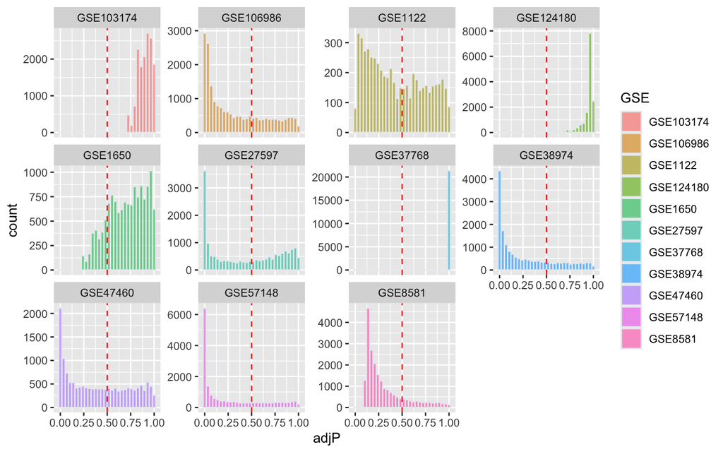

```r
#pdf("Pvalues.pdf",width = 8,height = 6)
adjp %>%
  group_by(GSE) %>%
  ggplot( aes(x=adjP, fill=GSE)) +
  geom_histogram( color="#e9ecef", alpha=0.6) + #position = 'identity'
  geom_vline(xintercept=0.5, linetype="dashed", color = "red") +
  facet_wrap(~GSE, scales = "free_y")
```

```r
#dev.off()

adj_pvalue <- 0.5
adjp <- filter(adjp,adjP < adj_pvalue)
unique(adjp$GSE)
```

```
## [1] "GSE27597"  "GSE106986" "GSE57148"  "GSE47460"  "GSE38974"  "GSE8581"
## [7] "GSE1650"   "GSE1122"   "GSE124180"
```

```r
adjp
```

```
## # A tibble: 81,919 x 3
##    GENE.SYMBOL GSE          adjP
##    <chr>       <chr>       <dbl>
##  1 IL1R2       GSE27597 1.57e-31
##  2 SLCO4A1     GSE27597 7.88e-31
##  3 FKBP5       GSE27597 2.29e-29
##  4 SH3PXD2B    GSE27597 8.67e-24
##  5 GALNTL2     GSE27597 1.81e-23
##  6 IRAK3       GSE27597 2.83e-23
##  7 TIMP4       GSE27597 5.20e-22
##  8 CEACAM4     GSE27597 6.94e-22
##  9 SULT1B1     GSE27597 1.99e-21
## 10 ITGA10      GSE27597 3.21e-21
## # … with 81,909 more rows
```

```r
# log fold change
logFC <- full_tables %>%
  filter(GENE.SYMBOL != "NA") %>%
  gather("GSE"  ,"logFC",-GENE.SYMBOL) %>%
  filter(GSE %in% str_subset(colnames(full_tables),"logFC")) %>%
  mutate(GSE=gsub(".*_","",GSE))

logFC
```

```
## # A tibble: 265,419 x 3
##    GENE.SYMBOL GSE      logFC
##    <chr>       <chr>    <dbl>
##  1 IL1R2       GSE27597 -4.00
##  2 SLCO4A1     GSE27597 -2.83
##  3 FKBP5       GSE27597 -2.69
##  4 SH3PXD2B    GSE27597 -1.55
##  5 GALNTL2     GSE27597 -1.68
##  6 IRAK3       GSE27597 -1.58
##  7 TIMP4       GSE27597 -1.84
##  8 CEACAM4     GSE27597 -1.64
##  9 SULT1B1     GSE27597 -2.10
## 10 ITGA10      GSE27597 -1.26
## # … with 265,409 more rows
```

```r
# recovering logFC values from genes with p value less than 0.01

ap <- left_join(adjp,logFC,by = c("GENE.SYMBOL" = "GENE.SYMBOL", "GSE" = "GSE")) %>%
  select(-adjP) %>%
  spread(GSE,logFC) %>%
  replace(is.na(.), 0)

ap
```

```
## # A tibble: 23,159 x 10
##    GENE.SYMBOL GSE106986 GSE1122 GSE124180 GSE1650 GSE27597 GSE38974 GSE47460
##    <chr>           <dbl>   <dbl>     <dbl>   <dbl>    <dbl>    <dbl>    <dbl>
##  1 A1BG          -0.377        0         0       0   0.0915    0.437   0
##  2 A1BG-AS1       0.212        0         0       0   0         0       0
##  3 A1CF          -0.265        0         0       0   0         0       0
##  4 A2LD1          0.191        0         0       0   0.0893    0       0
##  5 A2M            1.11         0         0       0   0.130    -0.335  -0.0848
##  6 A2M-AS1        0            0         0       0   0         0       0
##  7 A2ML1         -0.0526       0         0       0   0         0.160   0
##  8 A2MP1          0            0         0       0   0         0       0
##  9 A3GALT2        0            0         0       0   0         0       0
## 10 A4GALT         0.287        0         0       0  -0.322     0       0
## # … with 23,149 more rows, and 2 more variables: GSE57148 <dbl>, GSE8581 <dbl>
```

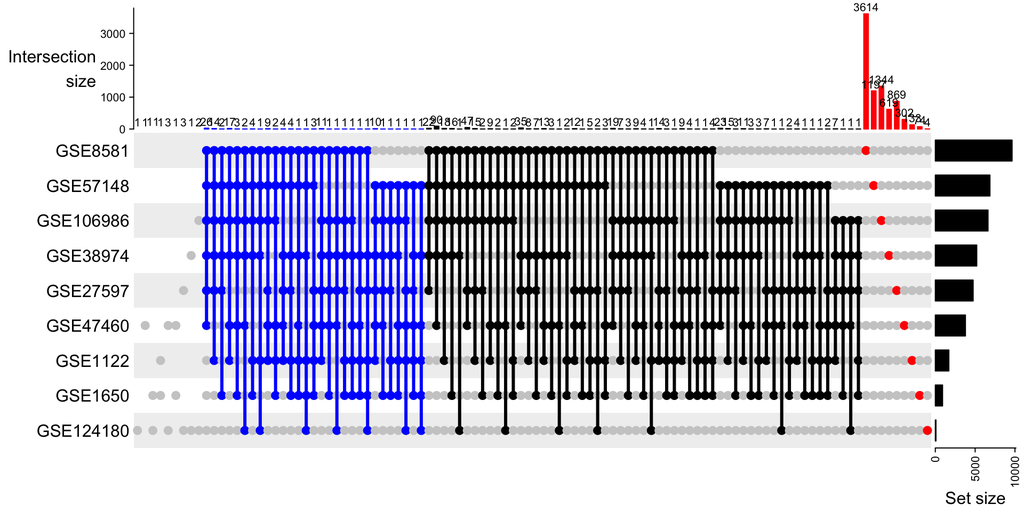

```r
# selecting up regulated genes
up <- ap %>%
  mutate_at(vars(-GENE.SYMBOL),list(~if_else( .>0, 1, 0)))

down <- ap %>%
  mutate_at(vars(-GENE.SYMBOL),list(~if_else( .<0, 1, 0)))

### UP
m <- make_comb_mat(up,mode = "distinct")
m <- m[comb_degree(m) >= 5 | comb_degree(m) == 1]

#pdf("upsetUP.pdf",width = 14,height = 6)
ht <- draw(UpSet(m,
      pt_size = unit(3, "mm"),
      lwd = 3,
      comb_col = c("red", "grey","grey","grey", "black","blue")[comb_degree(m)])
      #order.by = "freq"
    )

od = column_order(ht)
cs = comb_size(m)
decorate_annotation("Intersection\nsize", {
    grid.text(cs[od], x = seq_along(cs), y = unit(cs[od], "native") + unit(2, "pt"),
        default.units = "native", just = "bottom", gp = gpar(fontsize = 8))
})
```

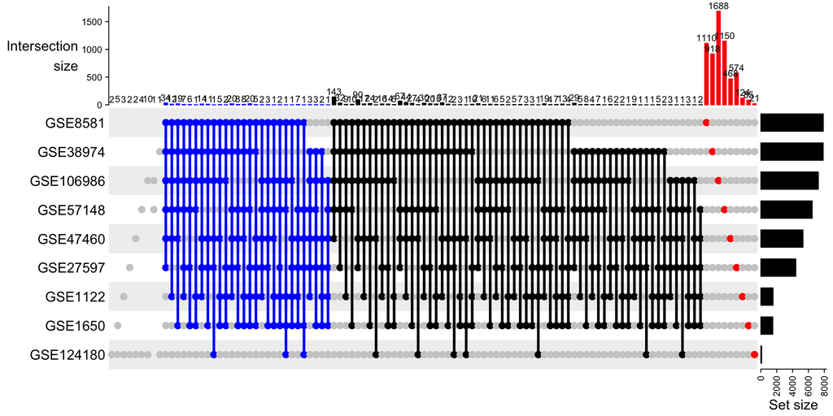

```r
#dev.off()


### DOWN
m <- make_comb_mat(down,mode = "distinct")
m <- m[comb_degree(m) >= 5 | comb_degree(m) == 1]

#pdf("upsetDOWN.pdf",width = 14,height = 6)
ht <- draw(UpSet(m,
      pt_size = unit(3, "mm"),
      lwd = 3,
      comb_col = c("red", "grey","grey","grey", "black","blue")[comb_degree(m)])
      #order.by = "freq"
    )
#dev.off()

od = column_order(ht)
cs = comb_size(m)
decorate_annotation("Intersection\nsize", {
    grid.text(cs[od], x = seq_along(cs), y = unit(cs[od], "native") + unit(2, "pt"),
        default.units = "native", just = "bottom", gp = gpar(fontsize = 8))
})
```

## Meta-analysis

We first calculate the Standar error using confidence intervals

```r
CI.R <- str_subset(colnames(full_tables),"CI.R")
CI.L <- str_subset(colnames(full_tables),"CI.L")

for(i in 1:length(CI.R)) {
  full_tables[str_c("SE_",gsub(".*_","",CI.R))] <- (full_tables[,CI.R]-full_tables[,CI.L]) /(2*1.96)
}
```

Meta-analysis for a single gene

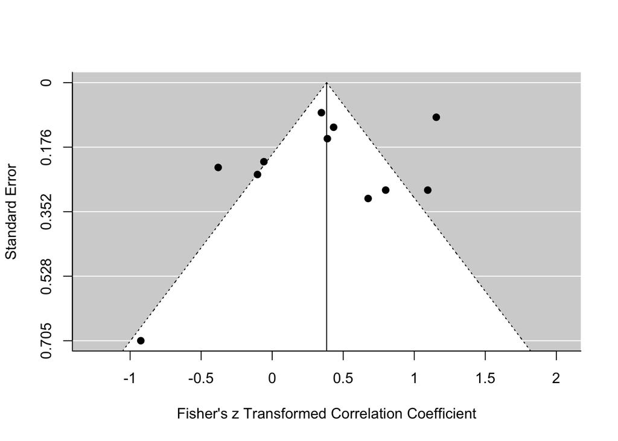

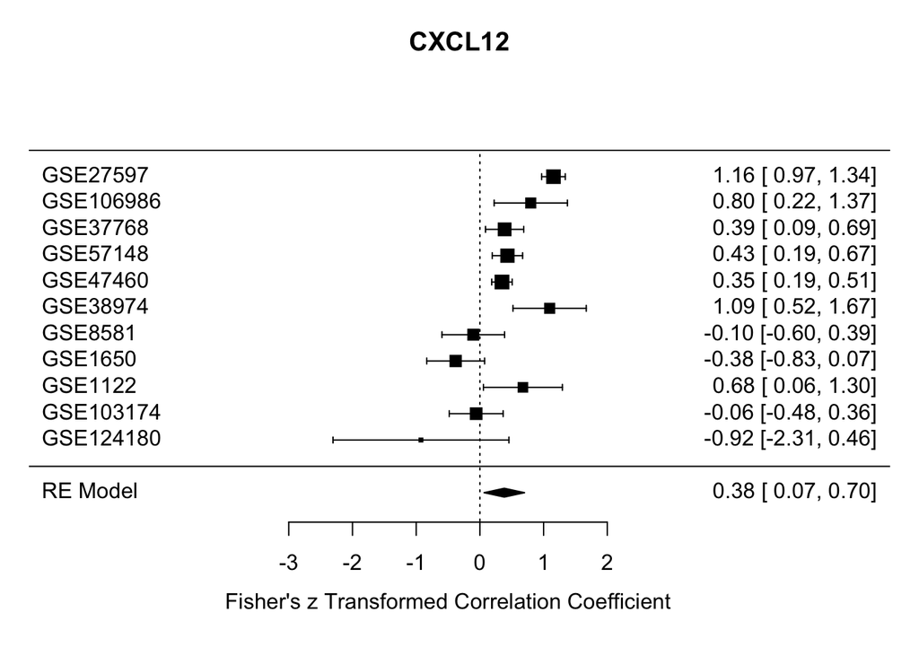

```r
FC <- str_subset(colnames(full_tables),"logFC")
SE <- str_subset(colnames(full_tables),"SE_")
GSE <- gsub(".*_","",FC)

gs <- "CXCL12"

## Funtion to perform a meta-analysis per gene
meta.plot <- function(gs){
gene <-  full_tables[full_tables$GENE.SYMBOL == gs,]
#gene <-  na.omit(full_tables[full_tables$GENE.SYMBOL == gs,])
gene <- gene[!is.na(gene$GENE.SYMBOL),]

dat <- data.frame(
  yi = as.numeric(gene[,FC]),
  sei = as.numeric(gene[,SE]),
  n1i = as.numeric(gse_table$CONTROL),
  n2i = as.numeric(gse_table$COPD)
)



dat <- escalc(measure="ZCOR", yi=yi,sei=sei,n1i=n1i,n2i=n2i, data = dat)

# meta analysis in the simplest way
res <- metafor::rma(yi, sei=sei,n1i=n1i,n2i=n2i, data=dat)
funnel(res)
forest(res,slab = GSE, main=unique(gene$GENE.SYMBOL))
}

meta.plot(gs)
```

Meta-analysis for all genes. We are saving the results in a new dataframe.

```r
#gs <- unique(na.omit(full_tables)$GENE.SYMBOL)
gs <- full_tables$GENE.SYMBOL


meta <- data.frame(genes = 0,
                   QEp=0,
                   estimate=0,
                   pval=0,
                   se=0,
                   H2=0,
                   tau2=0,
                   I2=0,
                   num_exp=0)

gm <- full_tables$GENE.SYMBOL
full_tables[full_tables == 0] <- NA

length(gm)
```

```
## [1] 24129
```

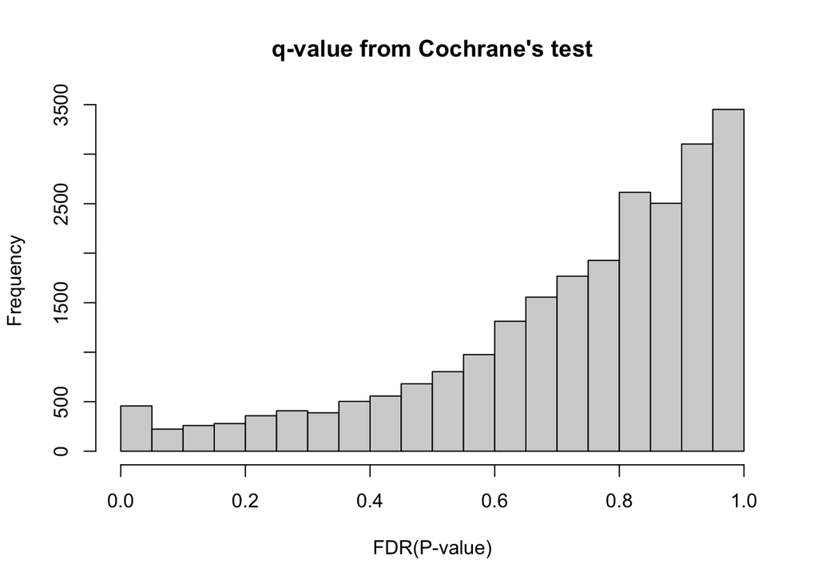

```r
for (i in gm) {
  gene <- full_tables[which(full_tables$GENE.SYMBOL == i),]
  yi <- as.numeric(gene[,FC])
  sei <- as.numeric(gene[,SE])
  num_exp <- sum(!is.na(yi))
  # meta analysis with random models "REML"
  res <- suppressWarnings(metafor::rma(yi, sei=sei,control=list(stepadj=.5,maxiter=1000)))
  num_exp <- sum(!is.na(yi))
  meta <- rbind(meta,c(i,res$QEp,res$beta,res$pval,res$se,res$H2,res$tau2,res$I2,num_exp))
}



meta <- meta[-1,]
meta$QEp <- as.numeric(meta$QEp)
meta$pval <- as.numeric(meta$pval)

# FDR correction
meta$qval <- p.adjust(meta$pval,method="fdr")


write.csv(meta, OUTPUT(c(TODAY,"_Step6_meta-analysis.csv")))
# meta <- read.csv(OUTPUT("2020-10-08_Step6_meta-analysis.csv"))

hist(meta$qval, main="q-value from Cochrane's test", xlab="FDR(P-value)")
```

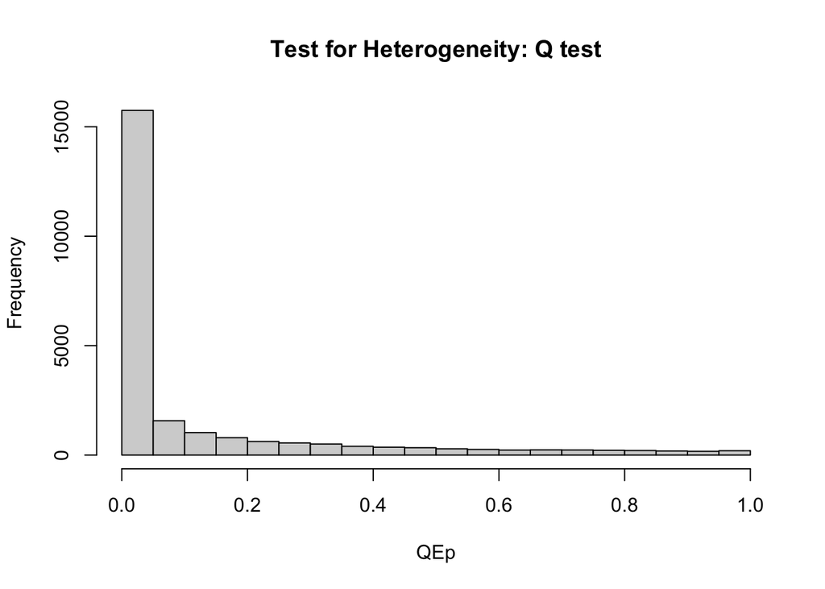

```r
hist(meta$QEp, main="Test for Heterogeneity: Q test", xlab="QEp")
```

```r
qval_cutoff <- 0.01
genesqval <- meta[meta$qval <= qval_cutoff,]
#genesqval <- genesqval[genesqval$QEp < 0.2,]
genesqval <-  genesqval[order(genesqval$qval),]

kable(genesqval, caption = "Meta-analysis")
```

Meta-analysis

|  | genes | QEp | estimate | pval | se | H2 | tau2 | I2 | num_exp | qval |
| --- | --- | --- | --- | --- | --- | --- | --- | --- | --- | --- |
| 1210 | PRODH | 0.8094274 | -0.719522415066499 | 0.00e+00 | 0.0997714314207075 | 1 | 0 | 0 | 4 | 0.0000000 |
| 17340 | FAM161B | 0.2148643 | -0.188011413724141 | 0.00e+00 | 0.0261092543255452 | 1.01916702079347 | 0.00011569519366208 | 1.88065551596739 | 8 | 0.0000000 |
| 4109 | PDK1 | 0.4625014 | 0.280307215627706 | 0.00e+00 | 0.0403143723225246 | 1.21455979973123 | 0.00310335830714499 | 17.6656431226121 | 11 | 0.0000000 |
| 674 | MGC29506 | 0.6710361 | 0.758578443540333 | 0.00e+00 | 0.111983103661156 | 1 | 0 | 0 | 3 | 0.0000001 |
| 24107 | SNORA70 | 0.1786676 | -0.981822613737902 | 0.00e+00 | 0.145235219947344 | 1.84587520119384 | 0.0270848271554184 | 45.8251565786658 | 3 | 0.0000001 |
| 1946 | GPIHBP1 | 0.7715917 | -0.462064542509047 | 0.00e+00 | 0.0688217833147715 | 1.03842146147854 | 0.00169952818796272 | 3.69998723098774 | 9 | 0.0000001 |
| 1294 | TMEM130 | 0.2679367 | 0.378216676516673 | 0.00e+00 | 0.0566350828717084 | 1.05702675589815 | 0.00165222902222948 | 5.39501536550008 | 9 | 0.0000001 |
| 2346 | ATP6V0D2 | 0.4329992 | 0.429769971511309 | 0.00e+00 | 0.0648878376338692 | 1.00001272880397 | 5.21642045915431e-07 | 0.00127286419462753 | 9 | 0.0000001 |
| 17394 | PKDCC | 0.2712141 | -0.314127272532528 | 0.00e+00 | 0.047934743772792 | 1.00028093760731 | 5.09955771485934e-06 | 0.0280858703533276 | 7 | 0.0000002 |
| 3988 | LAS1L | 0.0179296 | -0.0952020213982599 | 0.00e+00 | 0.0147373886410855 | 1.05904201340544 | 0.000119221518247063 | 5.57503976783558 | 9 | 0.0000002 |
| 17401 | EIF5AL1 | 0.4153010 | -0.283096146199715 | 0.00e+00 | 0.0437274817440294 | 1.00035009212151 | 3.72356307019292e-06 | 0.0349969599911929 | 3 | 0.0000002 |
| 2812 | C21orf96 | 0.5600740 | 0.323628153721892 | 0.00e+00 | 0.050993885197199 | 1 | 0 | 0 | 4 | 0.0000004 |
| 3626 | MMAB | 0.1255212 | -0.201720014799751 | 0.00e+00 | 0.031918469136066 | 1.00001409093004 | 1.3014850439412e-07 | 0.00140907314913419 | 8 | 0.0000005 |
| 16963 | HULC | 0.9490454 | -0.488176318358082 | 0.00e+00 | 0.0782475065759658 | 1 | 0 | 0 | 3 | 0.0000008 |
| 4219 | CCDC80 | 0.3375276 | 0.427018816146509 | 0.00e+00 | 0.0727209368505759 | 1.00008781774731 | 4.49932716097251e-06 | 0.00878100360350797 | 9 | 0.0000055 |
| 4570 | MAP2K6 | 0.1445338 | 0.145988349997405 | 0.00e+00 | 0.0248581455500815 | 1.00105329331282 | 7.79371422964695e-06 | 0.10521850533352 | 11 | 0.0000055 |
| 17053 | LOC642852 | 0.3847297 | 0.31532939347279 | 0.00e+00 | 0.0536944253119389 | 1.00012529889305 | 1.118477508125e-06 | 0.0125283195204409 | 3 | 0.0000055 |
| 20066 | BEX5 | 0.3885461 | -0.336837425603221 | 0.00e+00 | 0.0571571197642279 | 1.00007118114737 | 1.96039138358515e-06 | 0.00711760809708422 | 7 | 0.0000055 |
| 20261 | SLC25A51 | 0.7175063 | 0.219039003793665 | 0.00e+00 | 0.0372826375101085 | 1 | 0 | 0 | 4 | 0.0000055 |
| 2379 | CD163L1 | 0.1862830 | 0.241202903141244 | 0.00e+00 | 0.0418334415841219 | 1.00003431321167 | 5.75538317739172e-07 | 0.0034312034317683 | 9 | 0.0000098 |
| 6596 | TLE2 | 0.6067422 | -0.161610497030837 | 0.00e+00 | 0.0280902087492988 | 1.00022160728412 | 2.21012150728707e-06 | 0.0221558185214055 | 11 | 0.0000101 |
| 2871 | CD22 | 0.4609691 | 0.212851472448026 | 0.00e+00 | 0.0371457471683058 | 1.17062582909195 | 0.00198754310690499 | 14.5756077519925 | 10 | 0.0000110 |
| 15393 | MBOAT7 | 0.3034208 | 0.12305757404986 | 0.00e+00 | 0.0215514405679209 | 1.00025724775188 | 1.53929888385057e-06 | 0.0257181592496771 | 11 | 0.0000119 |
| 8708 | RPL23AP32 | 0.2850555 | -0.340908763958061 | 0.00e+00 | 0.0600953568491662 | 1.13306666214518 | 0.00271817944523525 | 11.7439393983451 | 6 | 0.0000141 |
| 6484 | SLC10A3 | 0.8927145 | -0.141050016526862 | 0.00e+00 | 0.0249498089437627 | 1 | 0 | 0 | 9 | 0.0000152 |
| 17264 | SNHG9 | 0.9890035 | -0.675082959435244 | 0.00e+00 | 0.120045437627934 | 1 | 0 | 0 | 3 | 0.0000174 |
| 8932 | WFS1 | 0.7831844 | -0.201667114660007 | 0.00e+00 | 0.0359423613863729 | 1 | 0 | 0 | 10 | 0.0000180 |
| 3331 | NBEAL2 | 0.8607123 | -0.136236951800276 | 0.00e+00 | 0.0243480107440405 | 1 | 0 | 0 | 10 | 0.0000190 |
| 4616 | SMOC2 | 0.0647449 | 0.351081021794365 | 0.00e+00 | 0.063632495811342 | 1.33550107694289 | 0.00851870477554937 | 25.1217376560182 | 9 | 0.0000286 |
| 2533 | TTC39C | 0.4465293 | 0.129993130160973 | 0.00e+00 | 0.0236447549723766 | 1.00100565576877 | 5.63388993958432e-06 | 0.100464544128861 | 9 | 0.0000309 |

[output cut: 149 more lines]

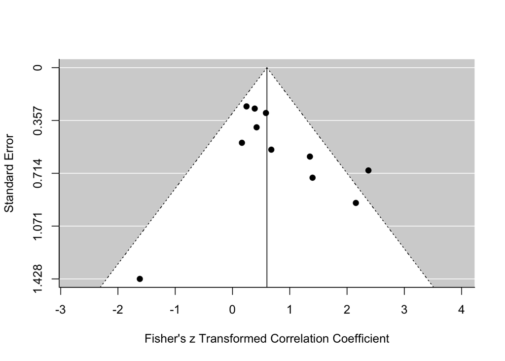

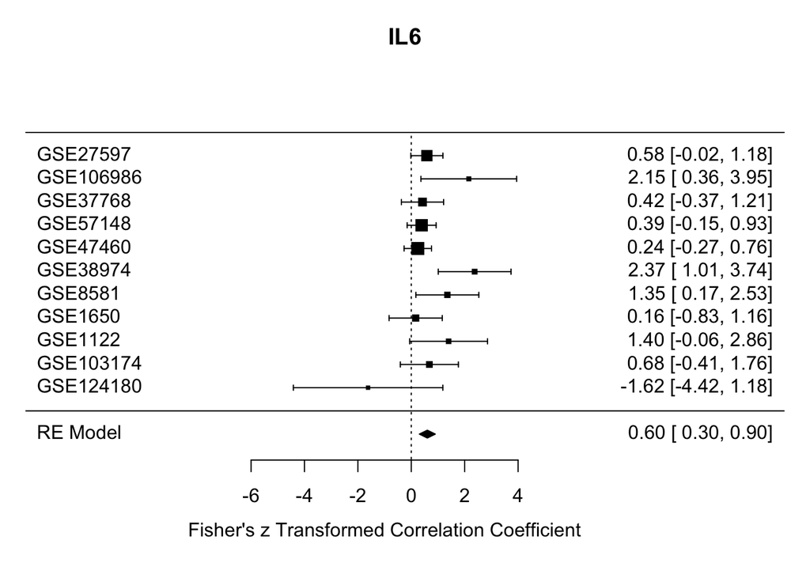

```r
up <- "IL6"
down <- "PRKCZ"
ace2 <- "ACE2"

meta.plot(up)
```

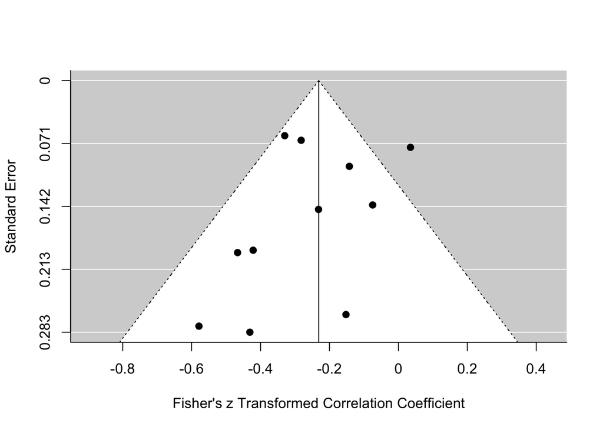

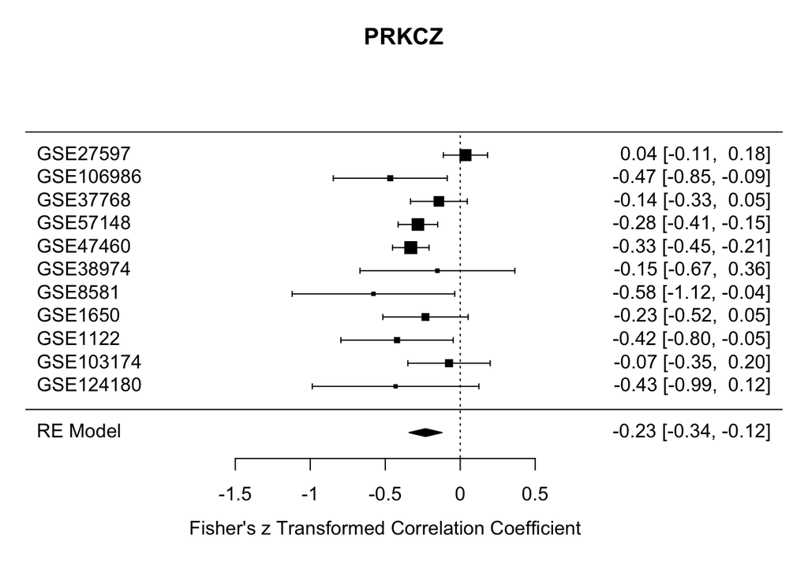

```r
meta.plot(down)
```

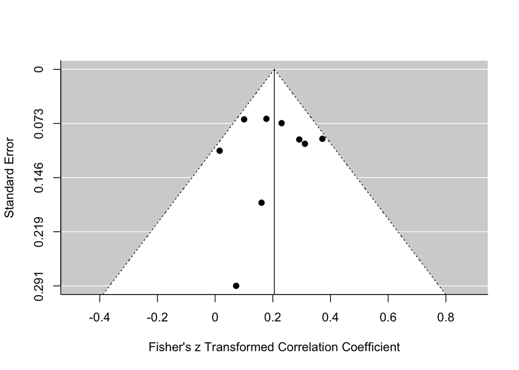

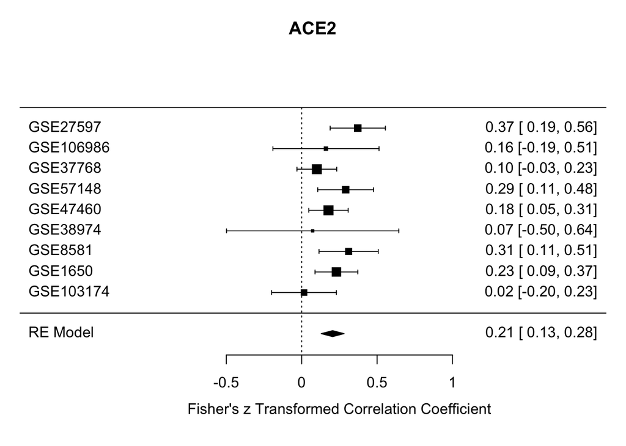

```r
meta.plot(ace2)
```

```r
topgenes <- full_tables[full_tables$GENE.SYMBOL %in% genesqval$genes,c("GENE.SYMBOL",FC)]
topgenes <- column_to_rownames(topgenes,"GENE.SYMBOL")

topgenes <- scale(topgenes)

# keeping genes with less than 2 NAs
topgenes <- topgenes[which(rowSums(is.na(topgenes)) <= 2),]
#topgenes <- na.omit(topgenes)

#ordering rows
#topgenes <- topgenes[order(rowMeans(topgenes),decreasing = T),]

#"BrBG"
color <- rev(colorRampPalette(brewer.pal(n = 11, name = "RdBu"))(15))
breaks <- c(seq(min(topgenes,na.rm = T),-0.1,length.out = 7),0,seq(0.1,max(topgenes,na.rm = T),length.out = 7))
```

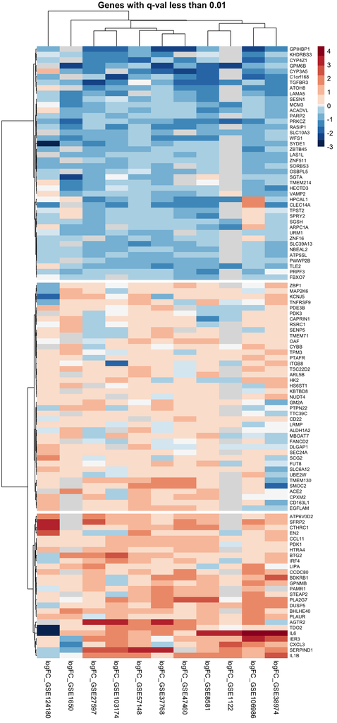

```r
pheatmap(topgenes,
         main = str_c("Genes with q-val less than ",qval_cutoff),
         color = color,
         breaks = breaks,
         fontsize_row = 7,
         fontsize_col = 10,
         cluster_rows = T,
         clustering_distance_rows = "euclidean",
         clustering_method = "ward.D",
         cluster_cols = T,
         cutree_rows = 3,
         show_colnames = T,
         border_color = NA)
```

### TFs

We also checked for expression in TFs

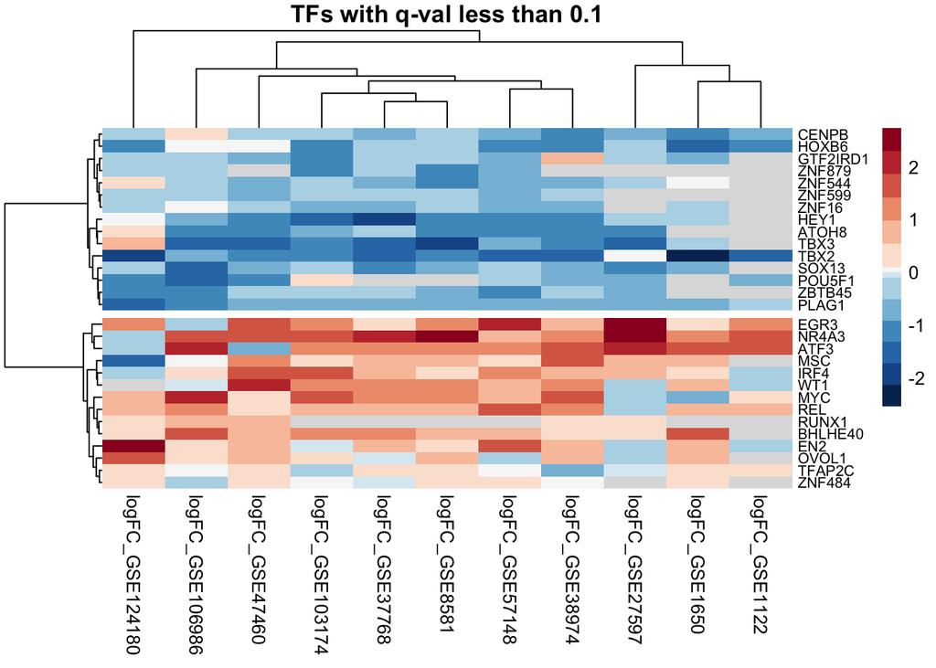

```r
tfs <- read.csv(DATA("hs_hgnc_curated_tfs.txt"),col.names = "TF")

qval_cutoff <- 0.1
genesqval <- meta[meta$qval <= qval_cutoff,]
tf_copd <- genesqval$genes[which(genesqval$genes %in% tfs$TF)]

topgenes <- full_tables[full_tables$GENE.SYMBOL %in% tf_copd,c("GENE.SYMBOL",FC)]
topgenes <- column_to_rownames(topgenes,"GENE.SYMBOL")
topgenes <- scale(topgenes)
#topgenes <- na.omit(topgenes)


color <- rev(colorRampPalette(brewer.pal(n = 11, name = "RdBu"))(15))
breaks <- c(seq(min(topgenes,na.rm = T),-0.1,length.out = 7),0,seq(0.1,max(topgenes,na.rm = T),length.out = 7))

pheatmap(topgenes,
         main = str_c("TFs with q-val less than ",qval_cutoff),
         color = color,
         breaks = breaks,
         fontsize_row = 8,
         fontsize_col = 10,
         cluster_rows = T,
         clustering_distance_rows = "euclidean",
         clustering_method = "ward.D",
         cluster_cols = T,
         cutree_rows = 2,
         show_colnames = T,
         border_color = NA)
```

## Output

This script produces the following data, and can be found in /Users/user/Documents/Doctorado/Analysis/Meta-analysis_COPD

**Plots:** Upset plots, forest plot, heatmap, etc.  
**Table:** Results from the meta-analysis /Users/user/Documents/Doctorado/Analysis/Meta-analysis_COPD/output_data/2020-10-16_Step6_meta-analysis.csv